# Final Report

Lee

2019-12-12

# 1 Modeling

```r
library(tidyverse)
```

## 1.1 Import Data

```r
df <- read.csv('./preprocessed.csv') %>% select(-X)
temp_corr <- colnames(df)
```

관광설문조사 데이터와 트립어드바이저 리뷰를 통해 얻어낸 LDA results를 join시키자.

```r
lda_results <- read.csv('LDA_results.csv') %>% select(-X)
df <- left_join(df, lda_results, by='category')
```

## 1.2 Modeling - Intro

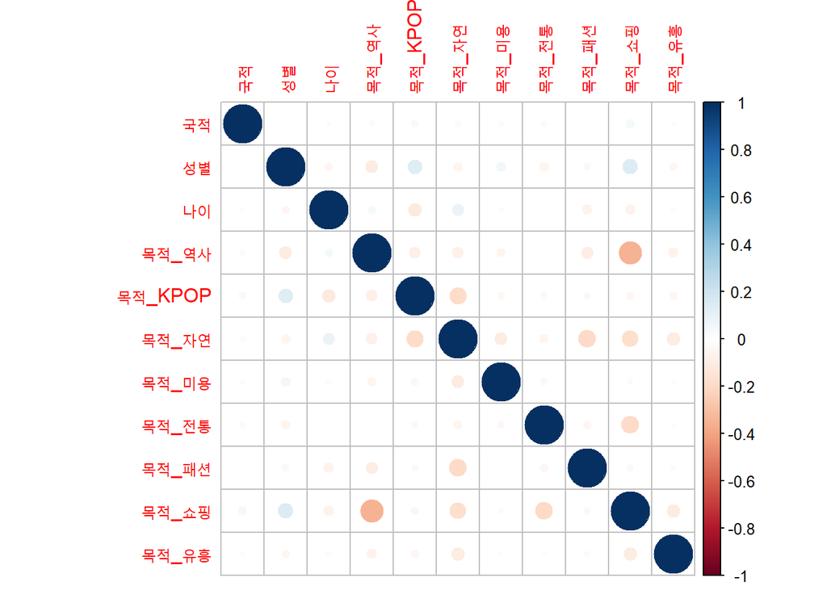

```r
library(corrplot)
test_corr <- df %>% select(temp_corr) %>% select(-category, -만족방문지)
test_corr <- as.data.frame(lapply(test_corr, as.integer))
test_corr %>% cor %>% corrplot
```

우리는 다중선형회귀 모형을 사용할 예정인 만큼 상관계수를 한번 보도록 하자.

각 변수들의 상관계수가 작은 편이기 때문에 **다변수 회귀 계수 해석**이 **안전**하다. (음과 양이 바뀌는 상황이 거의 없기 때문에)

```r
test1 <- df %>% select(starts_with('목적_'))

model1 <- lm(data=test1, df$topic1 ~ .)
model2 <- lm(data=test1, df$topic2 ~ .)
model3 <- lm(data=test1, df$topic3 ~ .)
model4 <- lm(data=test1, df$topic4 ~ .)
```

우선, **AIC**을 기준으로 **모델셀렉션(변수선택)**을 하여 토픽을 설명하는데 필요한 방문고려요인을 찾아보도록하자.

```r
stepmodel1 <- MASS::stepAIC(model1, direction = "both",trace = FALSE)
stepmodel2 <- MASS::stepAIC(model2, direction = "both",trace = FALSE)
stepmodel3 <- MASS::stepAIC(model3, direction = "both",trace = FALSE)
stepmodel4 <- MASS::stepAIC(model4, direction = "both",trace = FALSE)
```

### 1.2.1 (도시 - 조용한) ~ 방문고려요인

**유의한 방문고려요인들**

> 양 : 자연, 유흥

> 음 : 쇼핑

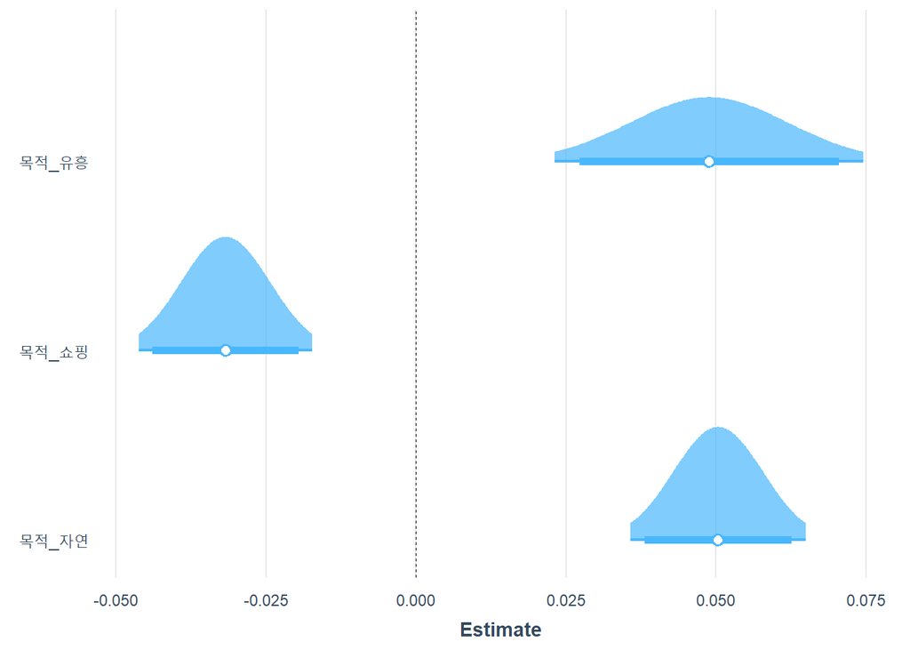

```r
#summary(stepmodel1)
significant <- broom::tidy(stepmodel1) %>%
    filter(abs(statistic) > 1.9) %>%
    filter(grepl('목적',term)) %>%
    pull(term)

jtools::plot_summs(stepmodel1, scale = TRUE, plot.distributions = TRUE, inner_ci_level = .9,
                   coefs = significant)
```

### 1.2.2 (도시 - 번화가의) ~ 방문고려요인

**유의한 방문고려요인들**

> 양 : K-POP, 미용, 패션, 쇼핑

> 음 : 역사, 자연

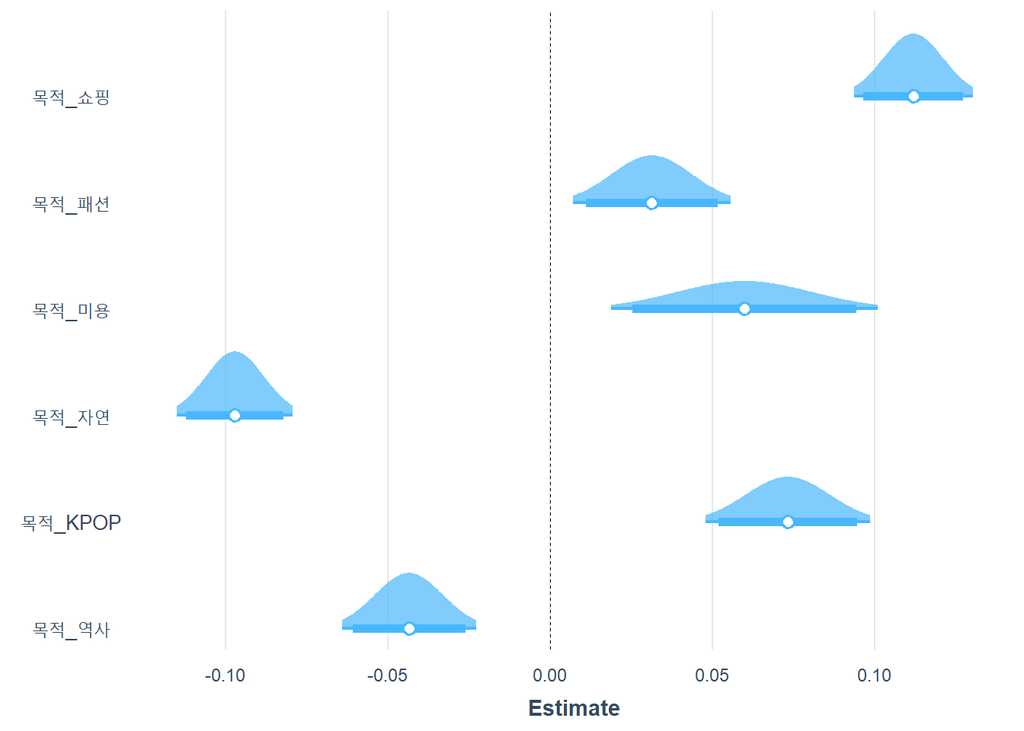

```r
#summary(stepmodel2)
significant <- broom::tidy(stepmodel2) %>%
    filter(abs(statistic) > 1.9) %>%
    filter(grepl('목적',term)) %>%
    pull(term)

jtools::plot_summs(stepmodel2, scale = TRUE, plot.distributions = TRUE, inner_ci_level = .9)
```

### 1.2.3 (역사 - 조용한) ~ 방문고려요인

**유의한 방문고려요인들**

> 양 : 역사, 전통

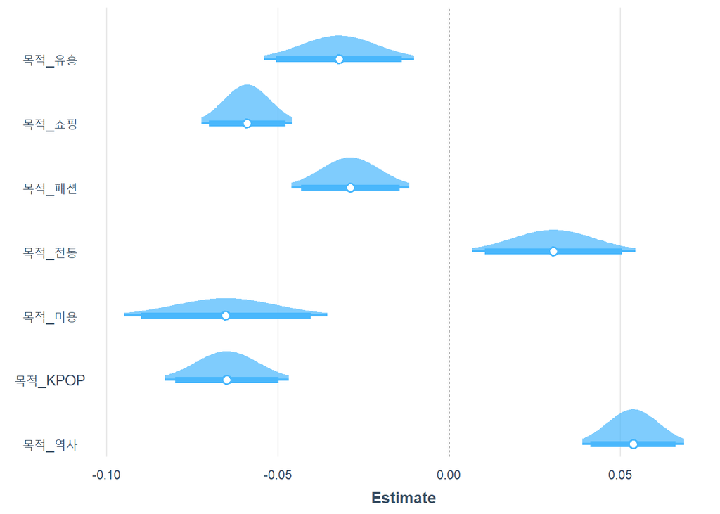

```r
#summary(stepmodel3)
significant <- broom::tidy(stepmodel3) %>%
    filter(abs(statistic) > 1.9) %>%
    filter(grepl('목적',term)) %>%
    pull(term)

jtools::plot_summs(stepmodel3, scale = TRUE, plot.distributions = TRUE, inner_ci_level = .9)
```

### 1.2.4 (자연 - 조용한) ~ 방문고려요인

**유의한 방문고려요인들**

> 양 : 자연

> 음 : 역사, K-POP, 전통, 쇼핑, 유흥

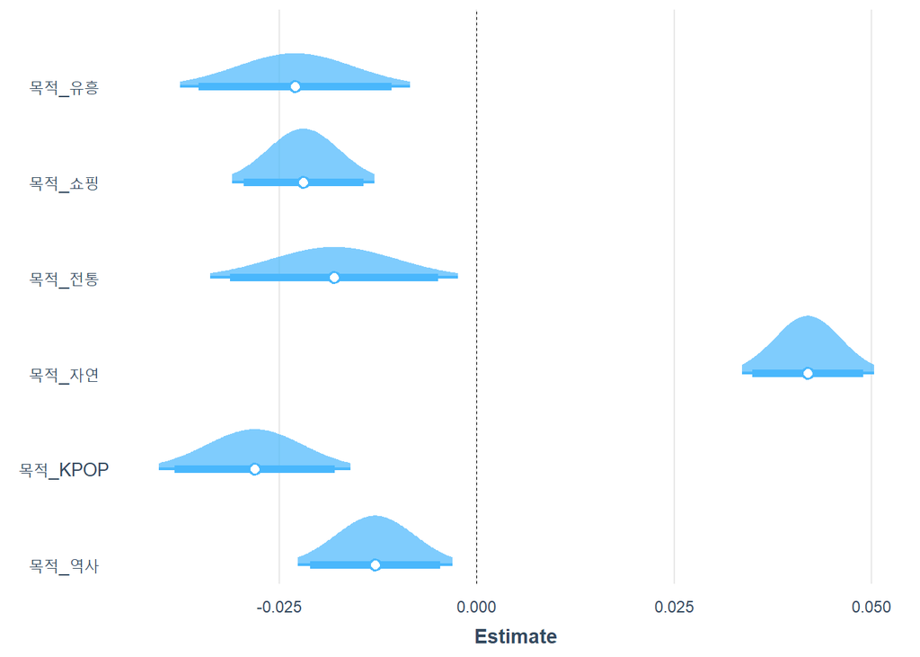

```r
#summary(stepmodel4)
significant <- broom::tidy(stepmodel4) %>%
    filter(abs(statistic) > 1.9) %>%
    filter(grepl('목적',term)) %>%
    pull(term)

jtools::plot_summs(stepmodel4, scale = TRUE, plot.distributions = TRUE, inner_ci_level = .9)
```

## 1.3 Modeling - Midtro

당연히 여행지 추천에서 당연히 방문 목적은 당연히 고려를 해야된다.

하지만 **과연 인구 통계정보를 고려하는 것이 맞을까?** 라는 질문에서 Midtro를 시작한다.

```r
demographic <- c('국적', '성별', '나이')
test_demographic <- df %>% select(topic1, topic2, topic3, topic4, demographic, category)
```

```r
pca <- prcomp(test_demographic %>% select(starts_with('topic')), scale. = FALSE) # topic 보존
summary(pca)
```

```
## Importance of components:
##                           PC1    PC2    PC3      PC4
## Standard deviation     0.5458 0.3915 0.2430 0.001109
## Proportion of Variance 0.5838 0.3004 0.1157 0.000000
## Cumulative Proportion  0.5838 0.8843 1.0000 1.000000
```

우선 PCA 2개의 주성분 만으로 88%의 분산이 설명되므로 2개로 간단하게 시각화를 진행하자.

### 1.3.1 PCA를 활용한 인구통계별 시각화

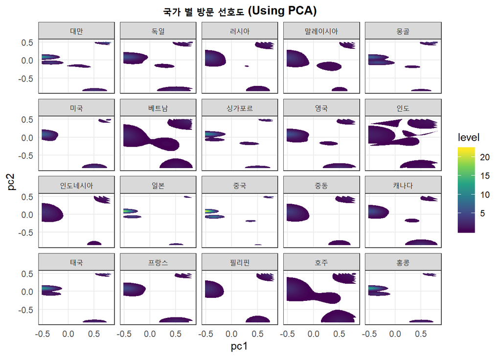

```r
test_demographic$pc1 <- pca$x[,1]
test_demographic$pc2 <- pca$x[,2]

ggplot(test_demographic, aes(pc1, pc2)) +
    stat_density_2d(aes(fill = stat(level)), geom = "polygon") +
    facet_wrap(.~국적)  + scale_fill_viridis_c() +
    theme_bw() +
    labs(title='국가 별 방문 선호도 (Using PCA)') +
    theme(plot.title = element_text(face = "bold", size = 12, hjust=0.5),
          axis.ticks = element_blank(),
          panel.grid.minor = element_blank())
```

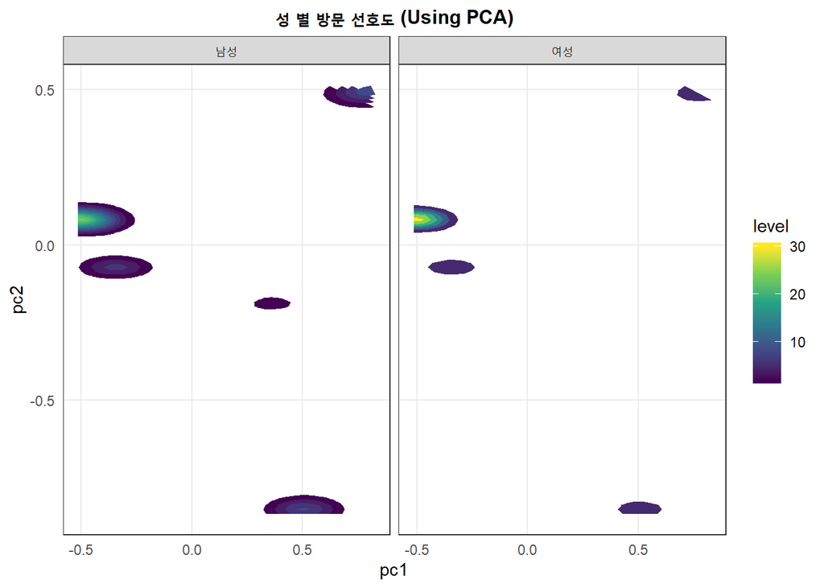

```r
ggplot(test_demographic, aes(pc1, pc2)) +
    stat_density_2d(aes(fill = stat(level)), geom = "polygon") +
    facet_wrap(.~성별)  + scale_fill_viridis_c() +
    theme_bw() +
    labs(title='성 별 방문 선호도 (Using PCA)') +
    theme(plot.title = element_text(face = "bold", size = 12, hjust=0.5),
          axis.ticks = element_blank(),
          panel.grid.minor = element_blank())
```

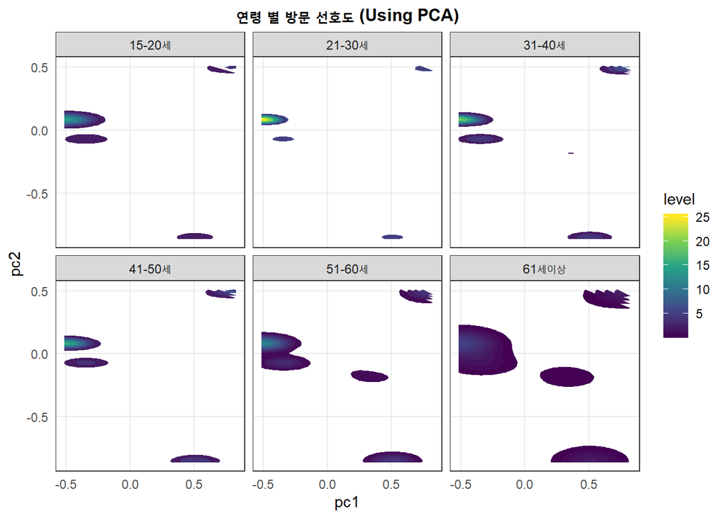

```r
ggplot(test_demographic, aes(pc1, pc2)) +
    stat_density_2d(aes(fill = stat(level)), geom = "polygon") +
    facet_wrap(.~나이)  + scale_fill_viridis_c() +
    theme_bw() +
    labs(title='연령 별 방문 선호도 (Using PCA)') +
    theme(plot.title = element_text(face = "bold", size = 12, hjust=0.5),
          axis.ticks = element_blank(),
          panel.grid.minor = element_blank())
```

### 1.3.2 Q : 국적은 여행 선호도에 영향이 있을까?

> 방문 목적을 공변량처럼 생각하여 변수에 포함한 다음에 둔 다음에 선형회귀를 진행해보자.

```r
test2 <- test1
test2['국적'] <- df$국적
model1_2 <- update(model1, ~.+국적, data=test2)
model2_2 <- update(model2, ~.+국적, data=test2)
model3_2 <- update(model3, ~.+국적, data=test2)
model4_2 <- update(model4, ~.+국적, data=test2)

stepmodel1_2 <- MASS::stepAIC(model1_2, direction = "both",trace = FALSE)
stepmodel2_2 <- MASS::stepAIC(model2_2, direction = "both",trace = FALSE)
stepmodel3_2 <- MASS::stepAIC(model3_2, direction = "both",trace = FALSE)
stepmodel4_2 <- MASS::stepAIC(model4_2, direction = "both",trace = FALSE)
```

#### 1.3.2.1 (도시 - 조용한)|방문목적 ~ 국적(대만 기준)

국적 변수는 모델셀렉션에서 선택이 되었고 동남아 국적의 경우 **(도시 - 조용한)**을 선호한다.

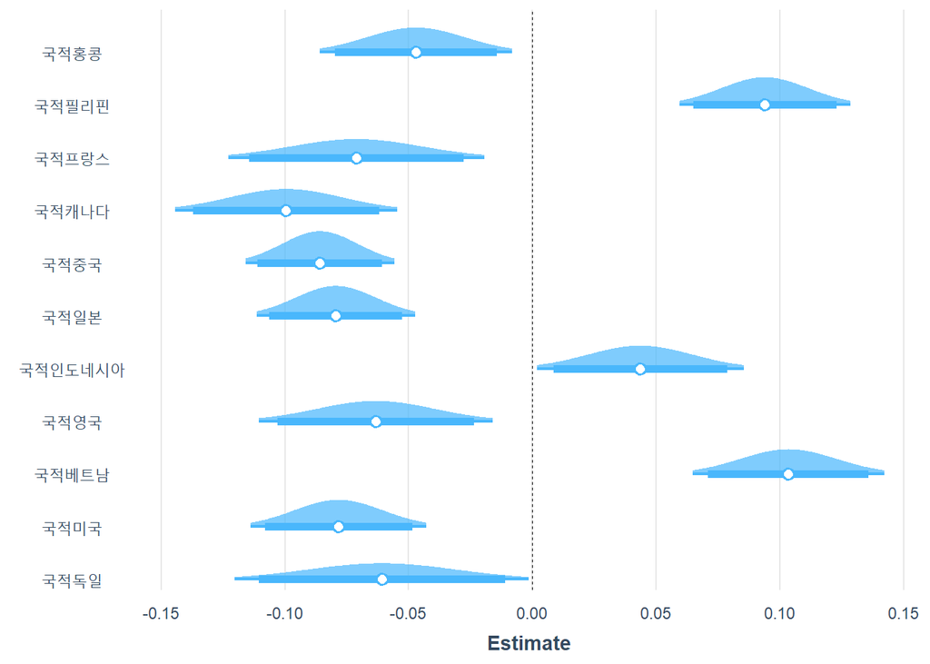

```r
#summary(stepmodel1_2)
significant <- broom::tidy(stepmodel1_2) %>%
    filter(abs(statistic) > 1.9) %>%
    filter(grepl('국적',term)) %>%
    pull(term)

jtools::plot_summs(stepmodel1_2, scale = TRUE, plot.distributions = TRUE, inner_ci_level = .9,
                   coefs = significant)
```

#### 1.3.2.2 (도시 - 번화가의)|방문목적 ~ 국적(대만 기준)

국적 변수는 모델셀렉션에서 선택이 되었고 베트남 국적을 제외하고 **(도시 - 번화가의)**을 선호한다.

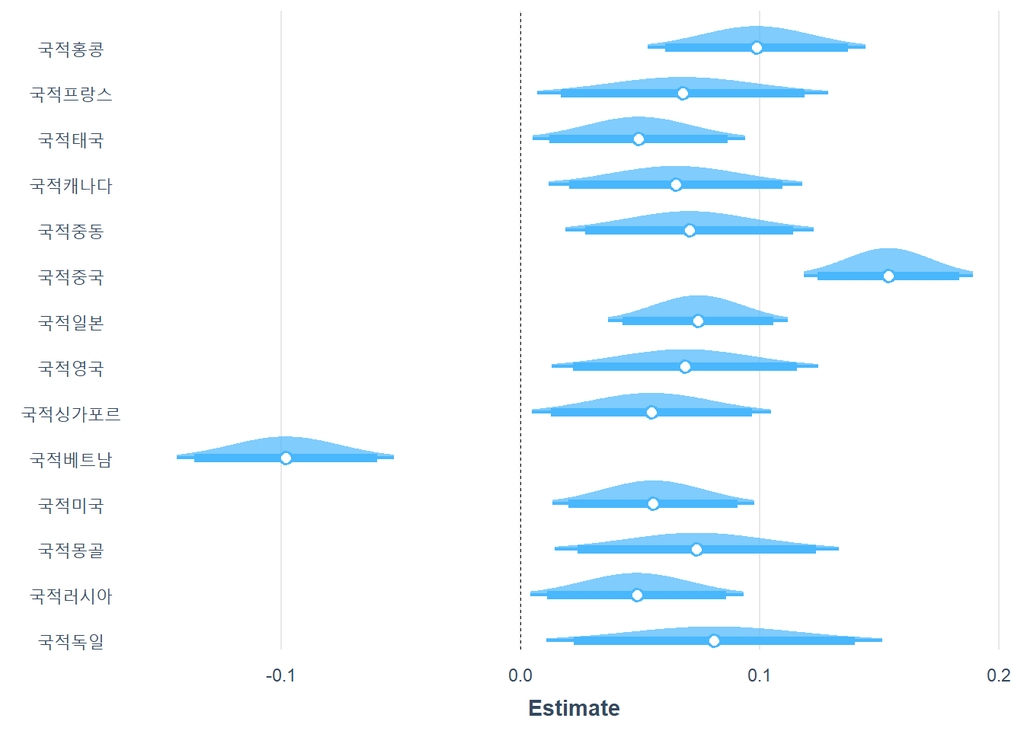

```r
#summary(stepmodel2_2)
significant <- broom::tidy(stepmodel2_2) %>%
    filter(abs(statistic) > 1.9) %>%
    filter(grepl('국적',term)) %>%
    pull(term)

jtools::plot_summs(stepmodel2_2, scale = TRUE, plot.distributions = TRUE, inner_ci_level = .9,
                   coefs = significant)
```

#### 1.3.2.3 (역사 - 조용한)|방문목적 ~ 국적(대만 기준)

국적 변수는 모델셀렉션에서 선택이 되었고 서양 국적은 **(역사 - 조용한)**을 선호한다.

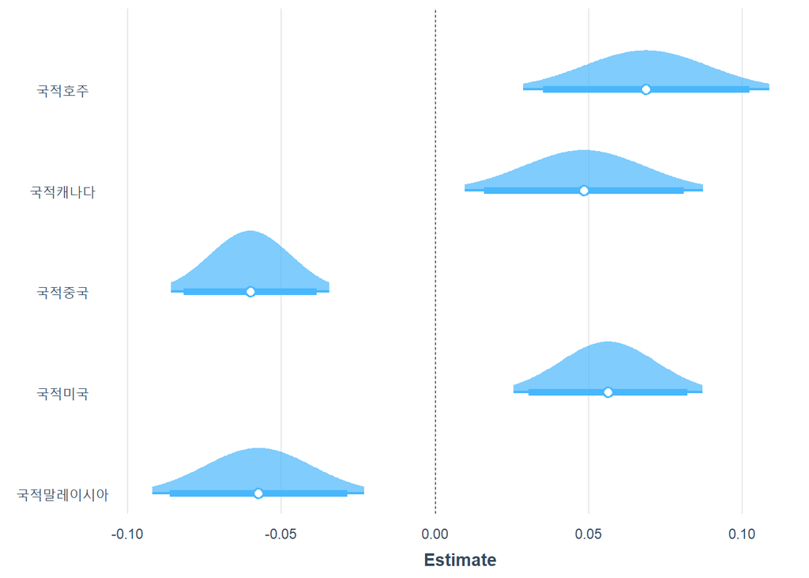

```r
#summary(stepmodel3_2)
significant <- broom::tidy(stepmodel3_2) %>%
    filter(abs(statistic) > 1.9) %>%
    filter(grepl('국적',term)) %>%
    pull(term)

jtools::plot_summs(stepmodel3_2, scale = TRUE, plot.distributions = TRUE, inner_ci_level = .9,
                   coefs = significant)
```

#### 1.3.2.4 (자연 - 조용한)|방문목적 ~ 국적(대만 기준)

국적 변수는 모델셀렉션에서 선택이 되었고 일본과 말레이시아가 **(자연 - 조용한)**을 선호한다.

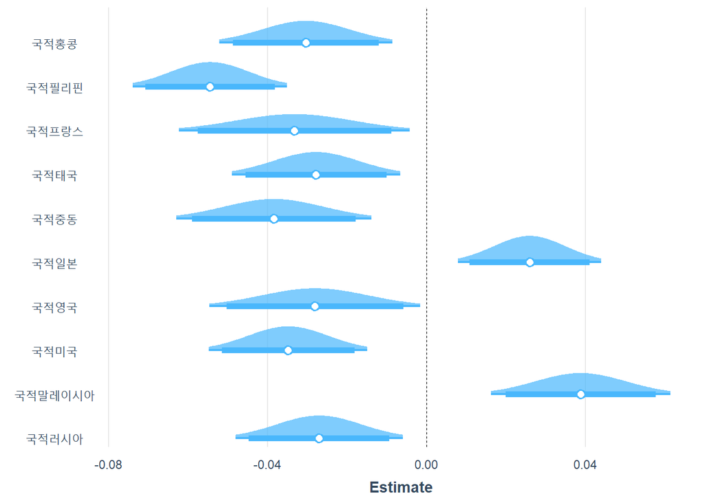

```r
#summary(stepmodel4_2)
significant <- broom::tidy(stepmodel4_2) %>%
    filter(abs(statistic) > 1.9) %>%
    filter(grepl('국적',term)) %>%
    pull(term)

jtools::plot_summs(stepmodel4_2, scale = TRUE, plot.distributions = TRUE, inner_ci_level = .9,
                   coefs = significant)
```

**Answer**

> AIC를 이용한 모델 셀렉션에서 선택된 것에 기반하여 **국적 변수**는 선택되었다.

### 1.3.3 Q : 성별은 여행 선호도에 영향이 있을까?

> 방문목적, 국적을 공변량처럼 생각하여 변수에 다 포함한 다음에 선형회귀를 진행해보자.

```r
test3 <- test2
test3['성별'] <- df$성별
model1_3 <- update(model1_2, ~.+성별, data=test3)
model2_3 <- update(model2_2, ~.+성별, data=test3)
model3_3 <- update(model3_2, ~.+성별, data=test3)
model4_3 <- update(model4_2, ~.+성별, data=test3)
```

```r
stepmodel1_3 <- MASS::stepAIC(model1_3, direction = "both",trace = FALSE)
stepmodel2_3 <- MASS::stepAIC(model2_3, direction = "both",trace = FALSE)
stepmodel3_3 <- MASS::stepAIC(model3_3, direction = "both",trace = FALSE)
stepmodel4_3 <- MASS::stepAIC(model4_3, direction = "both",trace = FALSE)
```

#### 1.3.3.1 (도시 - 조용한)|방문목적, 국적 ~ 성별

```r
if ( !any(grepl('성별', broom::tidy(stepmodel1_3)$term)) ){
    print('토픽1(도시 - 조용한) : 성별이 모델에 포함되지 않았다!')
}
```

```
## [1] "토픽1(도시 - 조용한) : 성별이 모델에 포함되지 않았다!"
```

#### 1.3.3.2 (도시 - 번화가의)|방문목적, 국적 ~ 성별

```r
if ( !any(grepl('성별', broom::tidy(stepmodel2_3)$term)) ){
    print('토픽2(도시 - 번화가의) : 성별이 모델에 포함되지 않았다!')
}
```

```
## [1] "토픽2(도시 - 번화가의) : 성별이 모델에 포함되지 않았다!"
```

#### 1.3.3.3 (역사 - 조용한)|방문목적, 국적 ~ 성별

```r
if ( !any(grepl('성별', broom::tidy(stepmodel3_3)$term)) ){
    print('토픽3(역사 - 조용한) : 성별이 모델에 포함되지 않았다!')
}
```

```
## [1] "토픽3(역사 - 조용한) : 성별이 모델에 포함되지 않았다!"
```

#### 1.3.3.4 (자연 - 조용한)|방문목적, 국적 ~ 성별

```r
if ( !any(grepl('성별', broom::tidy(stepmodel4_3)$term)) ){
    print('토픽4(자연 - 조용한) : 성별이 모델에 포함되지 않았다!')
}
```

```
## [1] "토픽4(자연 - 조용한) : 성별이 모델에 포함되지 않았다!"
```

**Answer**

> AIC를 이용한 모델 셀렉션에서 성별은 선택되지 않는다. 성별만 아는 것은 유의한 정보일 수 있으나 **방문 목적, 국가를 아는 상황**에선 의미가 없다고 볼 수 있다.

### 1.3.4 Q : 나이는 여행 선호도에 영향이 있을까?

> 방문목적, 국적을 공변량처럼 생각하여 변수에 다 포함한 다음에 선형회귀를 진행해보자.

```r
test4 <- test2
test4['나이'] <- df$나이
model1_4 <- update(model1_2, ~.+나이, data=test4)
model2_4 <- update(model2_2, ~.+나이, data=test4)
model3_4 <- update(model3_2, ~.+나이, data=test4)
model4_4 <- update(model4_2, ~.+나이, data=test4)
```

```r
stepmodel1_4 <- MASS::stepAIC(model1_4, direction = "both",trace = FALSE)
stepmodel2_4 <- MASS::stepAIC(model2_4, direction = "both",trace = FALSE)
stepmodel3_4 <- MASS::stepAIC(model3_4, direction = "both",trace = FALSE)
stepmodel4_4 <- MASS::stepAIC(model4_4, direction = "both",trace = FALSE)
```

#### 1.3.4.1 (도시 - 조용한)|방문목적, 국적 ~ 나이(10대기준)

```r
#summary(stepmodel1_4)

if ( !any(grepl('나이', broom::tidy(stepmodel1_4)$term)) ){
    print('토픽1(도시 - 조용한) : 나이가 모델에 포함되지 않았다!')
}else{
    significant <- broom::tidy(stepmodel1_4) %>%
    filter(abs(statistic) > 1.9) %>%
    filter(grepl('나이',term)) %>%
    pull(term)

    jtools::plot_summs(stepmodel1_4, scale = TRUE, plot.distributions = TRUE,
                       inner_ci_level = .9, coefs = significant)
}
```

```
## [1] "토픽1(도시 - 조용한) : 나이가 모델에 포함되지 않았다!"
```

#### 1.3.4.2 (도시 - 번화가의)|방문목적, 국적 ~ 나이(10대기준)

나이 변수는 **(도시 - 번화가의)** 모델셀렉션에서 선택이 되었고 30대부터는 확실히 덜 선호된다.

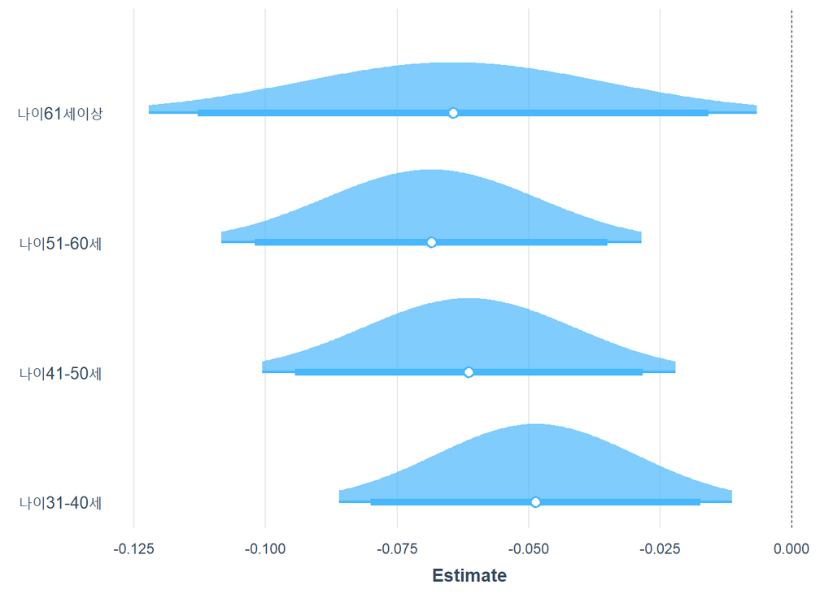

```r
# summary(stepmodel2_4)
if ( !any(grepl('나이', broom::tidy(stepmodel2_4)$term)) ){
    print('토픽2(도시 - 번화가의) : 나이가 모델에 포함되지 않았다!')
}else{
    significant <- broom::tidy(stepmodel2_4) %>%
    filter(abs(statistic) > 1.9) %>%
    filter(grepl('나이',term)) %>%
    pull(term)

    jtools::plot_summs(stepmodel2_4, scale = TRUE, plot.distributions = TRUE,
                       inner_ci_level = .9, coefs = significant)
}
```

#### 1.3.4.3 (역사 - 조용한)|방문목적, 국적 ~ 나이(10대기준)

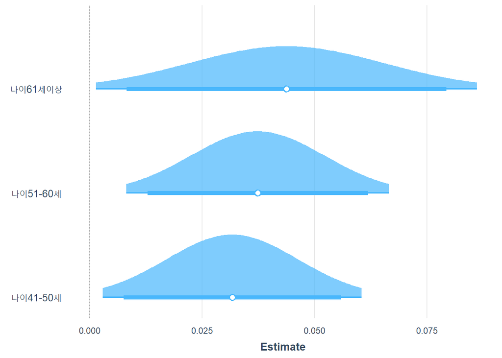

```r
# summary(stepmodel3_4)
if ( !any(grepl('나이', broom::tidy(stepmodel3_4)$term)) ){
    print('토픽3(역사 - 조용한) : 나이가 모델에 포함되지 않았다!')
}else{
    significant <- broom::tidy(stepmodel3_4) %>%
    filter(abs(statistic) > 1.9) %>%
    filter(grepl('나이',term)) %>%
    pull(term)

    jtools::plot_summs(stepmodel3_4, scale = TRUE, plot.distributions = TRUE,
                       inner_ci_level = .9, coefs = significant)
}
```

#### 1.3.4.4 (자연 - 조용한)|방문목적, 국적 ~ 나이(10대기준)

```r
# summary(stepmodel4_4)
if ( !any(grepl('나이', broom::tidy(stepmodel4_4)$term)) ){
    print('토픽4(자연 - 조용한) : 나이가 모델에 포함되지 않았다!')
}else{
    significant <- broom::tidy(stepmodel4_4) %>%
    filter(abs(statistic) > 1.9) %>%
    filter(grepl('나이',term)) %>%
    pull(term)

    jtools::plot_summs(stepmodel4_4, scale = TRUE, plot.distributions = TRUE,
                       inner_ci_level = .9, coefs = significant)
}
```

```
## [1] "토픽4(자연 - 조용한) : 나이가 모델에 포함되지 않았다!"
```

**Answer**

> AIC를 이용한 모델 셀렉션에서 **나이 변수**는 부분적으로 선택되었다.

## 1.4 Modeling - outro

```r
yhat1 <- predict(stepmodel1_4, newdata = df)
yhat2 <- predict(stepmodel2_4, newdata = df)
yhat3 <- predict(stepmodel3_4, newdata = df)
yhat4 <- predict(stepmodel4_4, newdata = df)

estimated_df <- data.frame(topic1 = yhat1, topic2 = yhat2, topic3 = yhat3, topic4 = yhat4)
```

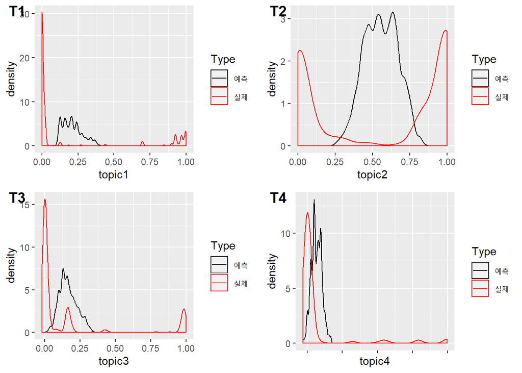

```r
t1 <- ggplot(estimated_df, aes(x=topic1, color='black')) + stat_density(geom='line') +
    geom_density(data=df, aes(color='red')) +
    scale_colour_manual(name = 'Type',
                        values =c('black'='black','red'='red'), labels = c('예측','실제'))

t2 <- ggplot(estimated_df, aes(x=topic2, color='black')) + stat_density(geom='line') +
    geom_density(data=df, aes(color='red')) +
    scale_colour_manual(name = 'Type',
                        values =c('black'='black','red'='red'), labels = c('예측','실제'))

t3 <- ggplot(estimated_df, aes(x=topic3, color='black')) + stat_density(geom='line') +
    geom_density(data=df, aes(color='red')) +
    scale_colour_manual(name = 'Type',
                        values =c('black'='black','red'='red'), labels = c('예측','실제'))

t4 <- ggplot(estimated_df, aes(x=topic4, color='black')) + stat_density(geom='line') +
    geom_density(data=df, aes(color='red')) +
    scale_colour_manual(name = 'Type',
                        values =c('black'='black','red'='red'), labels = c('예측','실제'))

ggpubr::ggarrange(t1, t2, t3, t4 + ggpubr::rremove("x.text"),
          labels = c("T1", "T2", "T3", 'T4'),
          ncol = 2, nrow = 2)
```

- 모델의 문제점

  > 1.우리 모형이 트렌드를 못따라간다.
  > 2. 검은색(estimated topic)에서 빨간색(actual value)으로 가는 적절한 변환을 못찾겠다.
- 원인 분석
  > 1. 방문목적과 인구통계를 활용한 선형회귀 모형의 설명력이 떨어져서 MSE를 낮추기 위한 평균부근으로 예측을 하게 된다.
  > 2. 토픽이 저렇게 어중간한 위치에 다 모이면 추천도 애매해지게 된다.
- 해결책

  > 그러므로 **rank**를 고려해서 변환하도록 하자.

```r
# 참고로 랭크 동률이 발생하면 맨 처음 것의 순위가 가장 낮음
ranking <- df %>%
    select(topic1, topic2, topic3, topic4) %>%
    mutate(topic1_rank = rank(topic1, ties.method = 'first'),
           topic2_rank = rank(topic2, ties.method = 'first'),
           topic3_rank = rank(topic3, ties.method = 'first'),
           topic4_rank = rank(topic4, ties.method = 'first'))
```

```r
ranking_estimated <- estimated_df %>%
    select(topic1, topic2, topic3, topic4) %>%
    transmute(topic1_rank = rank(topic1, ties.method = 'first'),
              topic2_rank = rank(topic2, ties.method = 'first'),
              topic3_rank = rank(topic3, ties.method = 'first'),
              topic4_rank = rank(topic4, ties.method = 'first'))
```

```r
temp1 <- left_join(ranking_estimated, ranking, by='topic1_rank') %>% pull(topic1)
temp2 <- left_join(ranking_estimated, ranking, by='topic2_rank') %>% pull(topic2)
temp3 <- left_join(ranking_estimated, ranking, by='topic3_rank') %>% pull(topic3)
temp4 <- left_join(ranking_estimated, ranking, by='topic4_rank') %>% pull(topic4)

r_estimated_df <- data.frame(topic1 = temp1,
                             topic2 = temp2,
                             topic3 = temp3,
                             topic4 = temp4)
```

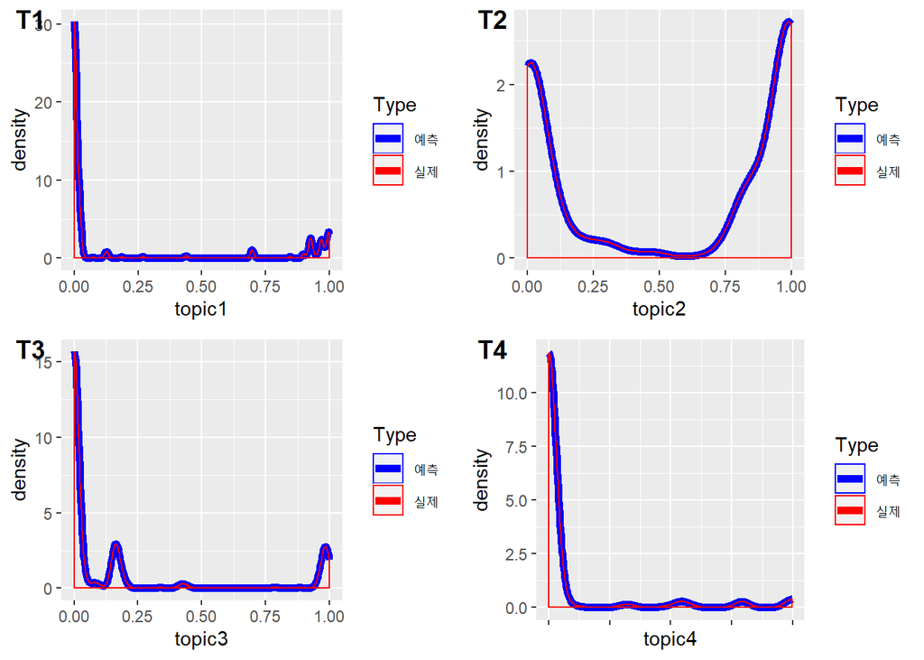

```r
t1 <- ggplot(r_estimated_df, aes(x=topic1, color='blue')) + stat_density(geom='line', size=2) +
    geom_density(data=df, aes(color='red')) +
    scale_colour_manual(name = 'Type',
                        values =c('blue'='blue','red'='red'), labels = c('예측','실제'))

t2 <- ggplot(r_estimated_df, aes(x=topic2, color='blue')) + stat_density(geom='line', size=2) +
    geom_density(data=df, aes(color='red')) +
    scale_colour_manual(name = 'Type',
                        values =c('blue'='blue','red'='red'), labels = c('예측','실제'))
t3 <- ggplot(r_estimated_df, aes(x=topic3, color='blue')) + stat_density(geom='line', size=2) +
    geom_density(data=df, aes(color='red')) +
    scale_colour_manual(name = 'Type',
                        values =c('blue'='blue','red'='red'), labels = c('예측','실제'))
t4 <- ggplot(r_estimated_df, aes(x=topic4, color='blue')) + stat_density(geom='line', size=2) +
    geom_density(data=df, aes(color='red')) +
    scale_colour_manual(name = 'Type',
                        values =c('blue'='blue','red'='red'), labels = c('예측','실제'))



ggpubr::ggarrange(t1, t2, t3, t4 + ggpubr::rremove("x.text"),
          labels = c("T1", "T2", "T3", 'T4'),
          ncol = 2, nrow = 2)
```

- 또 다른 문제점

  > 이 변환의 문제점은 토픽의 합이 1이 안되는 경우가 꽤 있다는 것이다.

  > 마지막 파트 **단순 유클리드 거리를 안쓰게 된 이유** 에서 해결하게 된다.

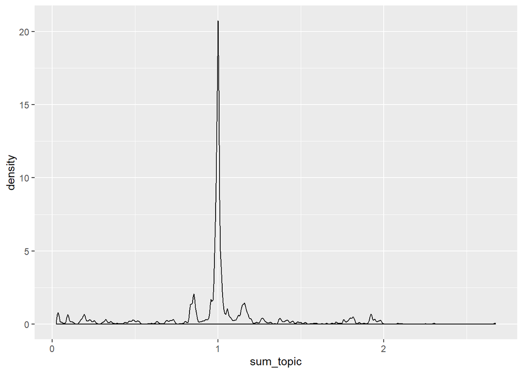

```r
temp_df <- data.frame(sum_topic=apply(r_estimated_df, 1, sum))
ggplot(temp_df ,aes(x=sum_topic)) + geom_density()
```

## 1.5 Pipeline

- 목표

  > 예측토픽에서 최근접 3가지의 여행지를 골라서 추천해주자.

Given {(40 - 1) 범주}로 묶은 관광지 리뷰로 학습한 LDA를 이용하여, {162개의 관광지}의 토픽을 뽑은 상황이다.

리니어 모델 피팅할 때는 설문조사 데이터에서 y인 **만족 방문지**가 **범주**로 묶여있어서 {(40 - 1) 범주}로 피팅하였는데

이미 선형회귀 모형을 피팅한 다음엔,

X변수인 국적, 목적, 연령 변수만 들어오면 관심 토픽을 예측할 수 있기 때문에, {162개의 관광지}의 토픽에서 가장 가까운 3개를 뽑아서 추천을 하도록 하자.

```r
lda_results2 <- read.csv('LDA_results2.csv') %>% select(-X)
```

이제 파이프 라인을 생각해보자.

일단 방문 고려요인, 인구통계정보가 들어온다.

그 다음 이미 학습된 선형회귀모형으로 예측을 하고 랭크 변환을 한다.

그 다음 예측된 토픽에서 최근접 3개의 여행지를 추천한다.

목적은 한번에 여러개 받지 말고 하나씩 나눠서 받도록 하자!

```r
input <- list()
input[['목적']] <- c('역사')
# '목적_역사','목적_K-POP','목적_자연','목적_미용','목적_전통','목적_패션','목적_쇼핑','목적_유흥'
# factor

input[['국적']] <- '미국'
# "대만" "독일""러시아" "말레이시아" "몽골" "미국" "베트남" "싱가포르" "영국"       "인도"       "인도네시아" "일본" "중국" "중동" "캐나다""태국""프랑스" "필리핀" "호주" "홍콩"
# factor

input[['나이']] <- '41-50세'
# "15-20세", "21-30세", "31-40세", "41-50세", "51-60세", "61세이상"
# factor
```

```r
input_df <- data.frame(목적_역사 = ifelse(any(input$목적 %in% '역사'), 1, 0),
                    목적_KPOP = ifelse(any(input$목적 %in% 'POP'), 1, 0),
                    목적_자연 = ifelse(any(input$목적 %in% '자연'), 1, 0),
                    목적_미용 = ifelse(any(input$목적 %in% '미용'), 1, 0),
                    목적_전통 = ifelse(any(input$목적 %in% '전통'), 1, 0),
                    목적_패션 = ifelse(any(input$목적 %in% '패션'), 1, 0),
                    목적_쇼핑 = ifelse(any(input$목적 %in% '쇼핑'), 1, 0),
                    목적_유흥 = ifelse(any(input$목적 %in% '유흥'), 1, 0),
                    국적 = input$국적,
                    나이= input$나이)
```

```r
yhat1 <- predict(model1_4, newdata=input_df)
yhat2 <- predict(model2_4, newdata=input_df)
yhat3 <- predict(model3_4, newdata=input_df)
yhat4 <- predict(model4_4, newdata=input_df)
```

랭크 기반 변환

1. 이제 이 yhat을 넣으면 우리의 샘플들로 만든 estimates들 사이에서 몇등에 속하는 지 알아내고
2. 실제 토픽들의 값에 등수에 기반해서 매핑해준다.

```r
temp1 <- ecdf(predict(model1_4, newdata=df))
temp2 <- ecdf(predict(model2_4, newdata=df))
temp3 <- ecdf(predict(model3_4, newdata=df))
temp4 <- ecdf(predict(model4_4, newdata=df))

r_yhat1 <- temp1(yhat1) # rank
r_yhat2 <- temp2(yhat2) # rank
r_yhat3 <- temp3(yhat3) # rank
r_yhat4 <- temp4(yhat4) # rank

# mapping under estimates's rank
temp1 <- ecdf(lda_results$topic1)
temp2 <- ecdf(lda_results$topic2)
temp3 <- ecdf(lda_results$topic3)
temp4 <- ecdf(lda_results$topic4)

real_yhat1 <- temp1(r_yhat1)
real_yhat2 <- temp2(r_yhat2)
real_yhat3 <- temp3(r_yhat3)
real_yhat4 <- temp4(r_yhat4)

##############################################################
########## SEE 단순 유클리드 거리를 안쓰게 된 이유 ###########
##############################################################
# result <- data.frame(topic1 =real_yhat1, topic2 = real_yhat2,
#                      topic3 = real_yhat3, topic4 = real_yhat4)

WEIGHTS <- c(5, 2.5, 1.5, 1)
real_yhats <- c(real_yhat1, real_yhat2, real_yhat3, real_yhat4)
ry_orders <- order(-real_yhats)
i = 1
for(ord in ry_orders){
    real_yhats[ord] <- real_yhats[ord] * WEIGHTS[i]
    i = i + 1
}
real_yhats = real_yhats / sum(real_yhats)

result <- data.frame(topic1 =real_yhats[1], topic2 = real_yhats[2],
                     topic3 = real_yhats[3], topic4 = real_yhats[4])
```

단순 유클리드를 안쓰기로 결정!

```r
eucl <- function(vector){
    sum(vector^2)
}

topic_location <- lda_results2 %>% select(topic1, topic2, topic3, topic4)

# Three attractions will be recommended
recoomend3 <- order(apply(topic_location - as.numeric(result), 1, eucl)) <= 3
recommend <- lda_results2[recoomend3,c('attraction')]
```

```r
write.csv(recommend, 'Three_recommendation.csv')
```

**단순 유클리드 거리를 안쓰게 된 이유**

실제 토픽은 4-심플렉스에 갇혀있고 Estimated 토픽은 심플렉스 바깥에 있기 때문에 토픽의 비중과 관련없는 것들이 뽑히게 된다.

예를 들어서 Estimated 토픽은 3이 가장 크지만 146번 토픽은 토픽3과 관련이 없다.

고로 이에 대한 해결 방법으로 **Estimated 토픽을 심플렉스로 Estimated 토픽의 순위에 따라서 가중치를 다르게 주며 가져오자**.

가중치를 주는 이유는 단순하게 합이 1이되도록 총합을 나눠주면 토픽이 애매해진다.

```r
result <- data.frame(topic1 =real_yhat1, topic2 = real_yhat2,
                     topic3 = real_yhat3, topic4 = real_yhat4)
result
```

```
##      topic1    topic2    topic3    topic4
## 1 0.6410256 0.6923077 0.9230769 0.7948718
```

```r
topic_location <- lda_results2 %>% select(topic1, topic2, topic3, topic4)

# Three attractions will be recommended
recoomend3 <- order(apply(topic_location - as.numeric(result), 1, eucl)) <= 3
lda_results2[recoomend3,] %>% select(topic1, topic2, topic3, topic4)
```

```
##         topic1    topic2     topic3    topic4
## 35  0.00000000 0.9829495 0.01254771 0.0000000
## 121 0.07242312 0.0000000 0.45227227 0.4746348
## 146 0.00000000 0.9923923 0.00000000 0.0000000
```